# Liner Regression Assignment

Muhammad Zikri bin Ab Aziz

10/23/2019

## Study Objective

This study aimed to predict the factors contribute to Family Stressor Score among staff nurse in Hospital C

**Outcome**: Family Stressor Score

**Covariate**: Age, Gender, Type of Ward, Personal Burnout Score, Work Burnout Score, Client Burnout Score

## Introduction

Data set used in this assignment is burnout score data. The researcher want to study how burnout score and other factors lead to high stress level among staff nurse in Hospital C

### Package activation used in the analysis

```r
library(foreign)
library(psych)
library(knitr)
library(broom)
library(MASS)
library(tidyverse)
```

```r
library(tidyr)
library(corrplot)
library(haven)
library(ggplot2)
```

## Entering Dataset

```r
data1<-read_sav('burnout stressor_1.sav')
summary(data1)
```

```
##      PartID          Gender               Age            Ward
##  Min.   :  1.00   Length:300         Min.   :23.00   Length:300
##  1st Qu.: 75.75   Class :character   1st Qu.:29.00   Class :character
##  Median :150.50   Mode  :character   Median :34.00   Mode  :character
##  Mean   :150.50                      Mean   :34.92
##  3rd Qu.:225.25                      3rd Qu.:39.00
##  Max.   :300.00                      Max.   :56.00
##      Weight          Height        PersonalBS        WorkBS
##  Min.   :57.00   Min.   :147.0   Min.   :1.000   Min.   :1.000
##  1st Qu.:64.00   1st Qu.:168.0   1st Qu.:1.998   1st Qu.:2.060
##  Median :72.00   Median :174.0   Median :2.490   Median :2.525
##  Mean   :71.46   Mean   :174.5   Mean   :2.576   Mean   :2.635
##  3rd Qu.:78.00   3rd Qu.:180.2   3rd Qu.:3.223   3rd Qu.:3.312
##  Max.   :86.00   Max.   :205.0   Max.   :4.000   Max.   :4.000
##     ClientBS        FamilySS
##  Min.   :1.040   Min.   :0.220
##  1st Qu.:2.175   1st Qu.:1.438
##  Median :2.740   Median :2.090
##  Mean   :2.761   Mean   :2.097
##  3rd Qu.:3.310   3rd Qu.:2.723
##  Max.   :4.000   Max.   :4.000
```

BMI data was not available in the dataset. The researcher want to convert height and weight to Bmi variable to be used in the analysis.

### Adding BMI variable

```r
data2<-(data1%>%mutate(Bmi=Weight/(Height/100)^2))
describe(data2)
```

```
##            vars   n   mean    sd median trimmed    mad    min    max
## PartID        1 300 150.50 86.75 150.50  150.50 111.19   1.00 300.00
## Gender*       2 300    NaN    NA     NA     NaN     NA    Inf   -Inf
## Age           3 300  34.92  7.50  34.00   34.08   7.41  23.00  56.00
## Ward*         4 300    NaN    NA     NA     NaN     NA    Inf   -Inf
## Weight        5 300  71.46  8.37  72.00   71.52  10.38  57.00  86.00
## Height        6 300 174.50 11.16 174.00  173.95   8.90 147.00 205.00
## PersonalBS    7 300   2.58  0.76   2.49    2.57   0.87   1.00   4.00
## WorkBS        8 300   2.64  0.84   2.52    2.64   0.96   1.00   4.00
## ClientBS      9 300   2.76  0.74   2.74    2.76   0.85   1.04   4.00
## FamilySS     10 300   2.10  0.82   2.09    2.08   0.96   0.22   4.00
## Bmi          11 300  23.64  3.56  22.86   23.22   1.79  17.45  37.39
##             range  skew kurtosis   se
## PartID     299.00  0.00    -1.21 5.01
## Gender*      -Inf    NA       NA   NA
## Age         33.00  0.94     0.42 0.43
## Ward*        -Inf    NA       NA   NA
## Weight      29.00 -0.11    -1.28 0.48
## Height      58.00  0.38     0.25 0.64
## PersonalBS   3.00  0.12    -0.85 0.04
## WorkBS       3.00  0.08    -0.98 0.05
## ClientBS     2.96  0.02    -0.86 0.04
## FamilySS     3.78  0.15    -0.75 0.05
## Bmi         19.94  1.39     2.48 0.21
```

## Descriptive Statistic

Summary of Data1 (Bmi not included in this dataset)

```r
summary(data1)
```

```
##      PartID          Gender               Age            Ward
##  Min.   :  1.00   Length:300         Min.   :23.00   Length:300
##  1st Qu.: 75.75   Class :character   1st Qu.:29.00   Class :character
##  Median :150.50   Mode  :character   Median :34.00   Mode  :character
##  Mean   :150.50                      Mean   :34.92
##  3rd Qu.:225.25                      3rd Qu.:39.00
##  Max.   :300.00                      Max.   :56.00
##      Weight          Height        PersonalBS        WorkBS
##  Min.   :57.00   Min.   :147.0   Min.   :1.000   Min.   :1.000
##  1st Qu.:64.00   1st Qu.:168.0   1st Qu.:1.998   1st Qu.:2.060
##  Median :72.00   Median :174.0   Median :2.490   Median :2.525
##  Mean   :71.46   Mean   :174.5   Mean   :2.576   Mean   :2.635
##  3rd Qu.:78.00   3rd Qu.:180.2   3rd Qu.:3.223   3rd Qu.:3.312
##  Max.   :86.00   Max.   :205.0   Max.   :4.000   Max.   :4.000
##     ClientBS        FamilySS
##  Min.   :1.040   Min.   :0.220
##  1st Qu.:2.175   1st Qu.:1.438
##  Median :2.740   Median :2.090
##  Mean   :2.761   Mean   :2.097
##  3rd Qu.:3.310   3rd Qu.:2.723
##  Max.   :4.000   Max.   :4.000
```

## Data Exploration and data wrangling

### Histogram

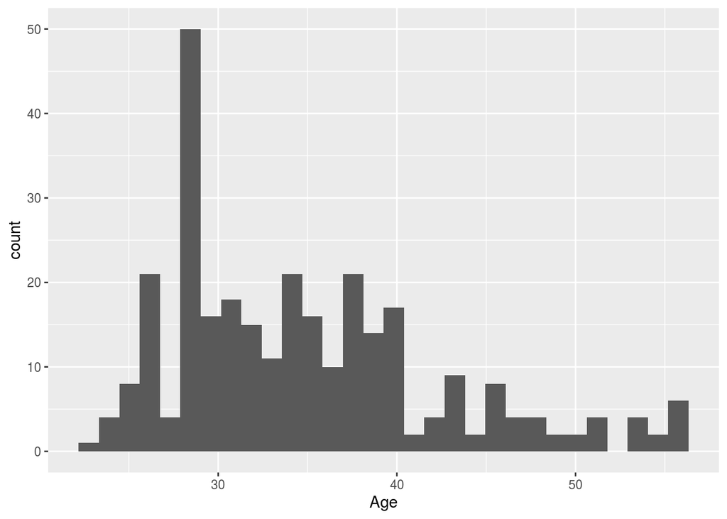

```r
ggplot(data2,aes(Age))+geom_histogram()
```

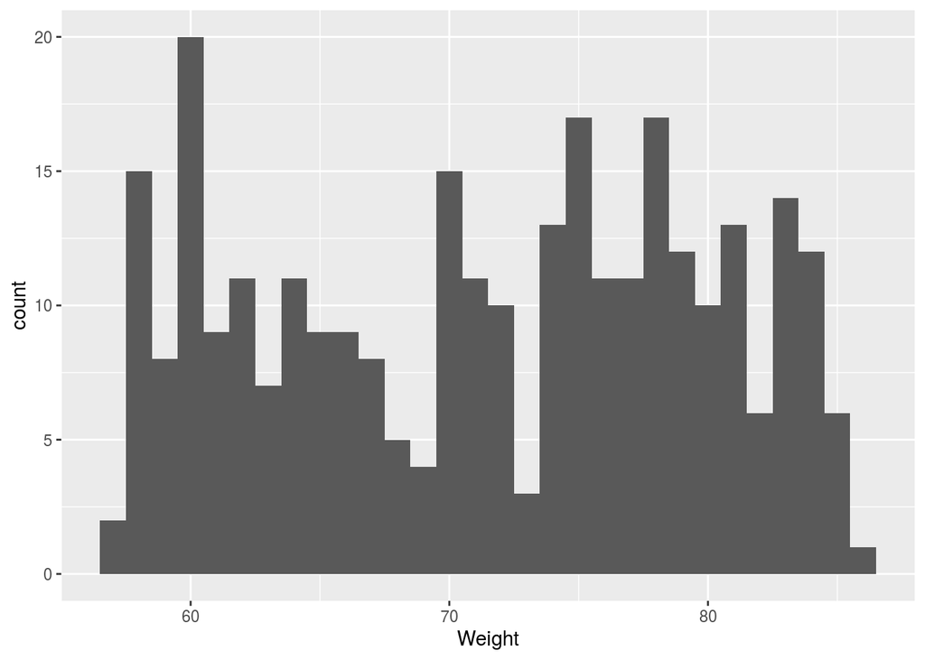

```r
ggplot(data2,aes(Weight))+geom_histogram()
```

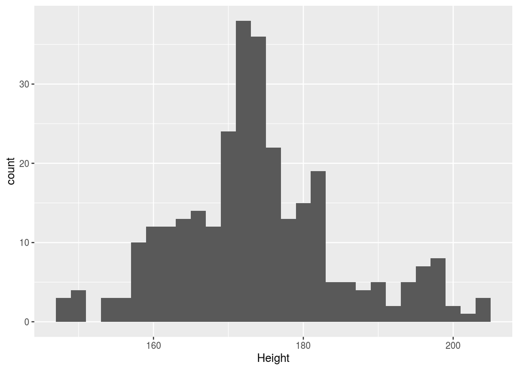

```r
ggplot(data2,aes(Height))+geom_histogram()
```

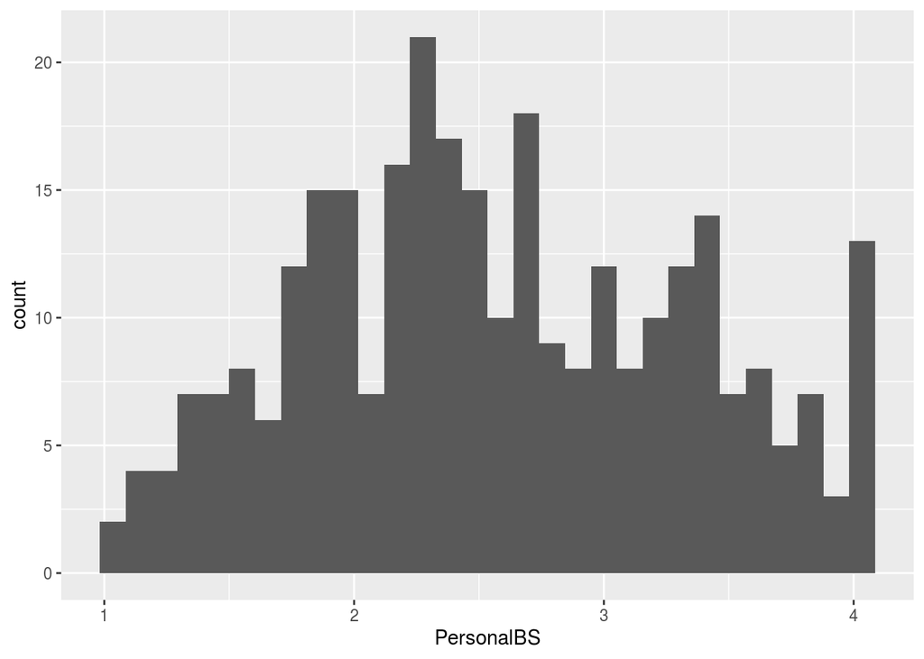

```r
ggplot(data2,aes(PersonalBS))+geom_histogram()
```

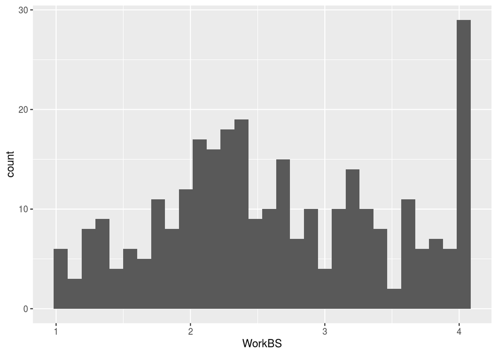

```r
ggplot(data2,aes(WorkBS))+geom_histogram()
```

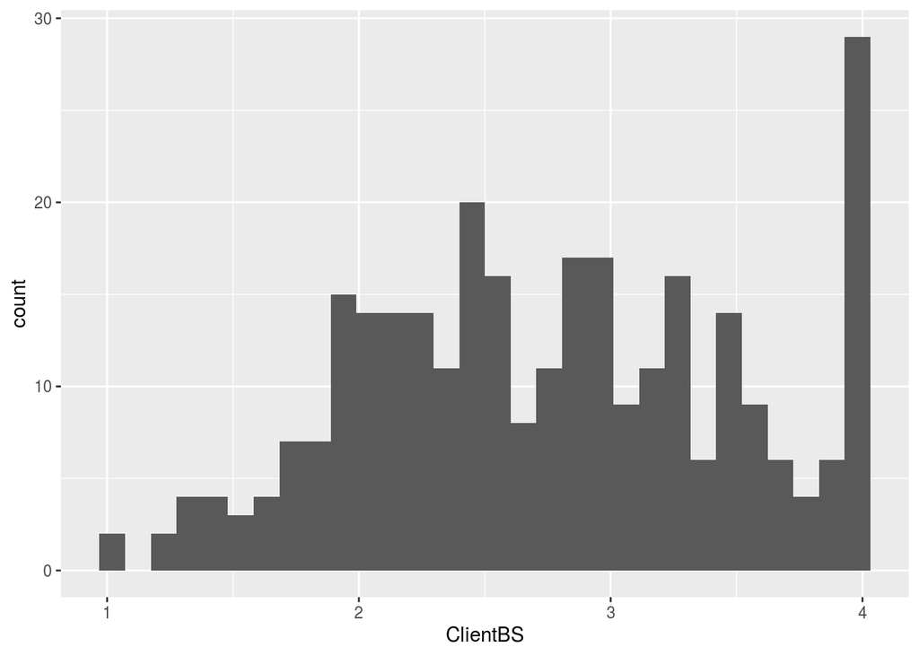

```r
ggplot(data2,aes(ClientBS))+geom_histogram()
```

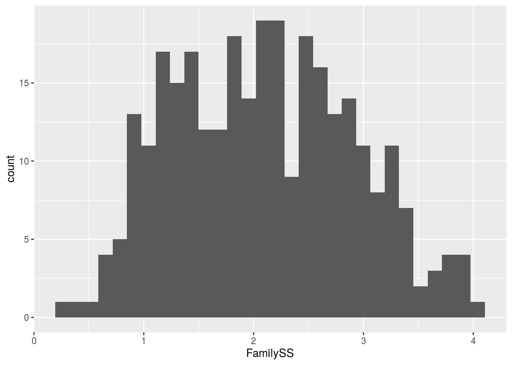

```r
ggplot(data2,aes(FamilySS))+geom_histogram()
```

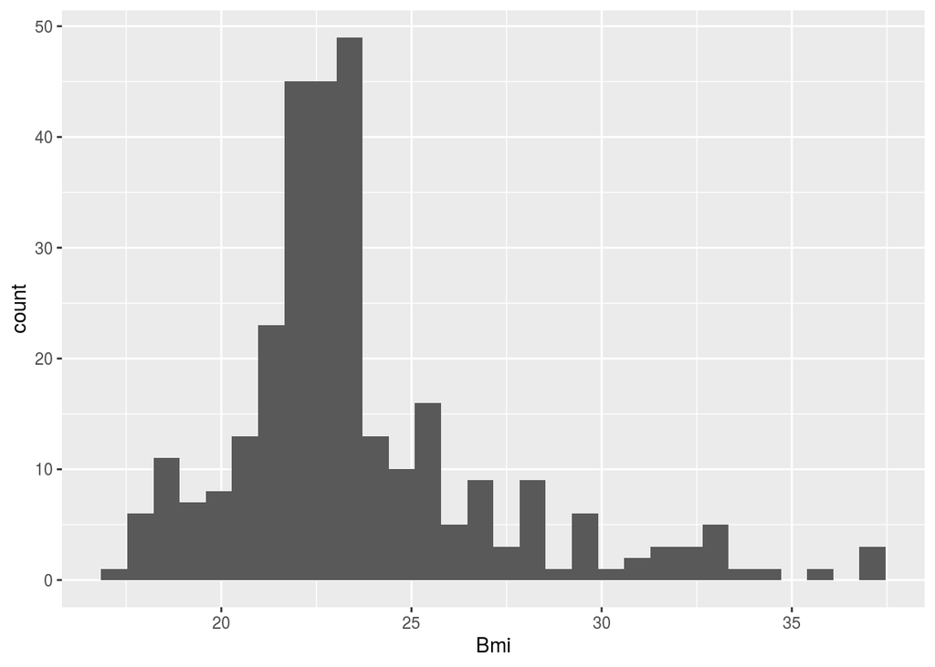

```r
ggplot(data2,aes(Bmi))+geom_histogram()
```

## Correlation Matrix

Researcher want to study correlation between covariates in the study by doing correlation matrix and correlogram

```r
data3<-data2%>%select_if(is.numeric)
cordata3<-cor(data3,use="complete.obs",method="pearson")
head(round(cordata3,2))
```

```
##            PartID   Age Weight Height PersonalBS WorkBS ClientBS FamilySS
## PartID       1.00 -0.10   0.02   0.02      -0.01   0.05     0.12    -0.01
## Age         -0.10  1.00  -0.05  -0.06       0.07  -0.07     0.04    -0.10
## Weight       0.02 -0.05   1.00   0.37      -0.04   0.01    -0.08     0.05
## Height       0.02 -0.06   0.37   1.00      -0.11   0.15    -0.02     0.05
## PersonalBS  -0.01  0.07  -0.04  -0.11       1.00   0.36     0.50     0.65
## WorkBS       0.05 -0.07   0.01   0.15       0.36   1.00     0.37     0.43
##              Bmi
## PartID     -0.01
## Age         0.02
## Weight      0.51
## Height     -0.60
## PersonalBS  0.07
## WorkBS     -0.12
```

### corrplot

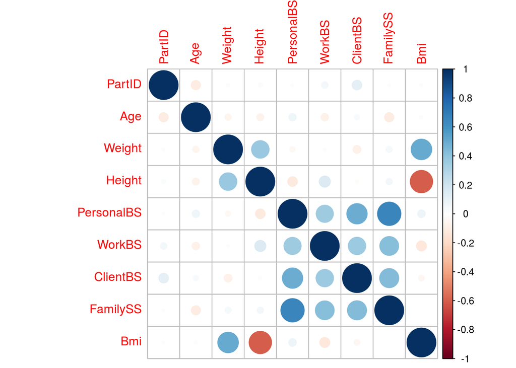

```r
corrplot(cordata3,method="circle")
```

## Statistical Analysis

### Univariable analysis - Linear Regression

Researcher used linear regression to predict factors contribute to Family Stressor Score

Assumptions in linear regression includes: 1. Independant Variables are non random 2. For each set of Independant Variables values, there is a subpopulation of Dependant Variable which are normally distributed. 3. The variance of subpopulation of dependant variable are all equal 4. The Independant variable value are independant of each other.

All assumption are met.

## Univariable Regression Analysis

Univariable regression analysis is done for all covariate by using simple linear regression

### model 1.1

**Association of Family Stressor Score with Age**

outcome : Family Stressor Score

covariate : Age

```r
modelAge1.1<-lm(FamilySS~Age, data2)
summary(modelAge1.1)
```

```
##
## Call:
## lm(formula = FamilySS ~ Age, data = data2)
##
## Residuals:
##      Min       1Q   Median       3Q      Max
## -1.83153 -0.68952 -0.01027  0.60361  1.91847
##
## Coefficients:
##              Estimate Std. Error t value Pr(>|t|)
## (Intercept)  2.490949   0.225308  11.056   <2e-16 ***
## Age         -0.011267   0.006308  -1.786   0.0751 .
## ---
## Signif. codes:  0 '***' 0.001 '**' 0.01 '*' 0.05 '.' 0.1 ' ' 1
##
## Residual standard error: 0.8186 on 298 degrees of freedom
## Multiple R-squared:  0.01059,    Adjusted R-squared:  0.007272
## F-statistic:  3.19 on 1 and 298 DF,  p-value: 0.07509
```

```r
tidy(modelAge1.1,conf.int = T)
```

```
## # A tibble: 2 x 7
##   term        estimate std.error statistic  p.value conf.low conf.high
##   <chr>          <dbl>     <dbl>     <dbl>    <dbl>    <dbl>     <dbl>
## 1 (Intercept)   2.49     0.225       11.1  4.87e-24   2.05     2.93
## 2 Age          -0.0113   0.00631     -1.79 7.51e- 2  -0.0237   0.00115
```

### model 1.2

**Association of Family Stressor Score with Gender**

Outcome : family stressor score

covariate : Gender

```r
modelGender1.2<-lm(FamilySS~Gender, data2)
summary(modelGender1.2)
```

```
##
## Call:
## lm(formula = FamilySS ~ Gender, data = data2)
##
## Residuals:
##      Min       1Q   Median       3Q      Max
## -1.83669 -0.63669 -0.01561  0.59689  1.87331
##
## Coefficients:
##             Estimate Std. Error t value Pr(>|t|)
## (Intercept)  2.05669    0.06826  30.129   <2e-16 ***
## GenderMale   0.07892    0.09497   0.831    0.407
## ---
## Signif. codes:  0 '***' 0.001 '**' 0.01 '*' 0.05 '.' 0.1 ' ' 1
##
## Residual standard error: 0.822 on 298 degrees of freedom
## Multiple R-squared:  0.002312,   Adjusted R-squared:  -0.001036
## F-statistic: 0.6907 on 1 and 298 DF,  p-value: 0.4066
```

```r
tidy(modelGender1.2,conf.int = T)
```

```
## # A tibble: 2 x 7
##   term        estimate std.error statistic  p.value conf.low conf.high
##   <chr>          <dbl>     <dbl>     <dbl>    <dbl>    <dbl>     <dbl>
## 1 (Intercept)   2.06      0.0683    30.1   1.88e-92    1.92      2.19
## 2 GenderMale    0.0789    0.0950     0.831 4.07e- 1   -0.108     0.266
```

### model 1.3

**Association of Family Stressor Score with Types of Ward**

outcome : Family Stressor Score

covariate : Types of Ward

```r
modelWard1.3<-lm(FamilySS~Ward, data2)
summary(modelWard1.3)
```

```
##
## Call:
## lm(formula = FamilySS ~ Ward, data = data2)
##
## Residuals:
##      Min       1Q   Median       3Q      Max
## -1.89096 -0.66212  0.00332  0.61404  1.88904
##
## Coefficients:
##                 Estimate Std. Error t value Pr(>|t|)
## (Intercept)      2.08562    0.06663  31.299   <2e-16 ***
## WardHighDep      0.02211    0.13137   0.168    0.866
## WardSpecialCare  0.02534    0.10802   0.235    0.815
## ---
## Signif. codes:  0 '***' 0.001 '**' 0.01 '*' 0.05 '.' 0.1 ' ' 1
##
## Residual standard error: 0.8242 on 297 degrees of freedom
## Multiple R-squared:  0.0002189,  Adjusted R-squared:  -0.006514
## F-statistic: 0.03251 on 2 and 297 DF,  p-value: 0.968
```

```r
tidy(modelWard1.3,conf.int = T)
```

```
## # A tibble: 3 x 7
##   term            estimate std.error statistic  p.value conf.low conf.high
##   <chr>              <dbl>     <dbl>     <dbl>    <dbl>    <dbl>     <dbl>
## 1 (Intercept)       2.09      0.0666    31.3   4.73e-96    1.95      2.22
## 2 WardHighDep       0.0221    0.131      0.168 8.66e- 1   -0.236     0.281
## 3 WardSpecialCare   0.0253    0.108      0.235 8.15e- 1   -0.187     0.238
```

### model 1.4

**Association of Family Stressor Score with Personal Burnout Score**

outcome : Family Stressor Score

covariate : Personal Burnout Score

```r
modelPersonalBS1.4<-lm(FamilySS~PersonalBS, data2)
summary(modelPersonalBS1.4)
```

```
##
## Call:
## lm(formula = FamilySS ~ PersonalBS, data = data2)
##
## Residuals:
##      Min       1Q   Median       3Q      Max
## -1.19167 -0.53684 -0.05985  0.49971  1.44578
##
## Coefficients:
##             Estimate Std. Error t value Pr(>|t|)
## (Intercept)  0.27248    0.12733    2.14   0.0332 *
## PersonalBS   0.70859    0.04743   14.94   <2e-16 ***
## ---
## Signif. codes:  0 '***' 0.001 '**' 0.01 '*' 0.05 '.' 0.1 ' ' 1
##
## Residual standard error: 0.6223 on 298 degrees of freedom
## Multiple R-squared:  0.4282, Adjusted R-squared:  0.4263
## F-statistic: 223.2 on 1 and 298 DF,  p-value: < 2.2e-16
```

```r
tidy(modelPersonalBS1.4,conf.int = T)
```

```
## # A tibble: 2 x 7
##   term        estimate std.error statistic  p.value conf.low conf.high
##   <chr>          <dbl>     <dbl>     <dbl>    <dbl>    <dbl>     <dbl>
## 1 (Intercept)    0.272    0.127       2.14 3.32e- 2   0.0219     0.523
## 2 PersonalBS     0.709    0.0474     14.9  4.72e-38   0.615      0.802
```

### model 1.5

**Association of Family Stressor Score with Work Burnout Score**

outcome : Family Stressor Score

covariate : Work Burnout Score

```r
modelWorkBS1.5<-lm(FamilySS~WorkBS, data2)
summary(modelWorkBS1.5)
```

```
##
## Call:
## lm(formula = FamilySS ~ WorkBS, data = data2)
##
## Residuals:
##      Min       1Q   Median       3Q      Max
## -2.02714 -0.52867 -0.03521  0.60602  1.82299
##
## Coefficients:
##             Estimate Std. Error t value Pr(>|t|)
## (Intercept)  0.99745    0.14174   7.037 1.35e-11 ***
## WorkBS       0.41742    0.05125   8.144 1.06e-14 ***
## ---
## Signif. codes:  0 '***' 0.001 '**' 0.01 '*' 0.05 '.' 0.1 ' ' 1
##
## Residual standard error: 0.7443 on 298 degrees of freedom
## Multiple R-squared:  0.1821, Adjusted R-squared:  0.1793
## F-statistic: 66.33 on 1 and 298 DF,  p-value: 1.056e-14
```

```r
tidy(modelWorkBS1.5,conf.int = T)
```

```
## # A tibble: 2 x 7
##   term        estimate std.error statistic  p.value conf.low conf.high
##   <chr>          <dbl>     <dbl>     <dbl>    <dbl>    <dbl>     <dbl>
## 1 (Intercept)    0.997    0.142       7.04 1.35e-11    0.719     1.28
## 2 WorkBS         0.417    0.0513      8.14 1.06e-14    0.317     0.518
```

### model 1.6

**Association of Family Stressor Score with Client Burnout Score**

outcome : Family Stressor Score

covariate : Client Burnout Score

```r
modelClientBS1.6<-lm(FamilySS~ClientBS, data2)
summary(modelClientBS1.6)
```

```
##
## Call:
## lm(formula = FamilySS ~ ClientBS, data = data2)
##
## Residuals:
##      Min       1Q   Median       3Q      Max
## -1.68783 -0.56854  0.03225  0.53141  1.87758
##
## Coefficients:
##             Estimate Std. Error t value Pr(>|t|)
## (Intercept)  0.74904    0.16514   4.536 8.32e-06 ***
## ClientBS     0.48842    0.05778   8.453 1.28e-15 ***
## ---
## Signif. codes:  0 '***' 0.001 '**' 0.01 '*' 0.05 '.' 0.1 ' ' 1
##
## Residual standard error: 0.7391 on 298 degrees of freedom
## Multiple R-squared:  0.1934, Adjusted R-squared:  0.1907
## F-statistic: 71.45 on 1 and 298 DF,  p-value: 1.284e-15
```

```r
tidy(modelClientBS1.6,conf.int = T)
```

```
## # A tibble: 2 x 7
##   term        estimate std.error statistic  p.value conf.low conf.high
##   <chr>          <dbl>     <dbl>     <dbl>    <dbl>    <dbl>     <dbl>
## 1 (Intercept)    0.749    0.165       4.54 8.32e- 6    0.424     1.07
## 2 ClientBS       0.488    0.0578      8.45 1.28e-15    0.375     0.602
```

### Model 1.7

**Association of Family Stressor Score with Bmi**

outcome : Family Stressor Score

covariate : Bmi

```r
modelBmi1.7<-lm(FamilySS~Bmi, data2)
summary(modelBmi1.7)
```

```
##
## Call:
## lm(formula = FamilySS ~ Bmi, data = data2)
##
## Residuals:
##      Min       1Q   Median       3Q      Max
## -1.87745 -0.66068 -0.00756  0.62404  1.90252
##
## Coefficients:
##               Estimate Std. Error t value Pr(>|t|)
## (Intercept)  2.1079611  0.3192498   6.603 1.85e-10 ***
## Bmi         -0.0004439  0.0133543  -0.033    0.974
## ---
## Signif. codes:  0 '***' 0.001 '**' 0.01 '*' 0.05 '.' 0.1 ' ' 1
##
## Residual standard error: 0.8229 on 298 degrees of freedom
## Multiple R-squared:  3.708e-06,  Adjusted R-squared:  -0.003352
## F-statistic: 0.001105 on 1 and 298 DF,  p-value: 0.9735
```

```r
tidy(modelBmi1.7,conf.int = T)
```

```
## # A tibble: 2 x 7
##   term         estimate std.error statistic  p.value conf.low conf.high
##   <chr>           <dbl>     <dbl>     <dbl>    <dbl>    <dbl>     <dbl>
## 1 (Intercept)  2.11        0.319     6.60   1.85e-10   1.48      2.74
## 2 Bmi         -0.000444    0.0134   -0.0332 9.74e- 1  -0.0267    0.0258
```

### Univariable Analysis FInding

**Based from univariable regression analysis, we found out that 3 covariate are significantly associate with Family Stressor Score which are Personal Burnout Score, WOrk Burnout Score, and Client Burnout Score. This will be considered in variable selection for modelling later**

Another variables (Age, Gender, BMI,Types of Ward) found to be not significant

As the association is not adjusted for other covariates, researcher will proceed with multivariable analysis to adjust the covariates.

## Multivariable analysis

### model2.1

Outcome : Family Stressor Score

Covariate : Personal Burnout Score,Work Burnout Score, Client Burnout Score

**this model contain covariates that are significantly associated with Family Stressor Score in univariable regression analysis**

```r
model2.1<-lm(FamilySS~PersonalBS+WorkBS+ClientBS, data = data2)
summary(model2.1)
```

```
##
## Call:
## lm(formula = FamilySS ~ PersonalBS + WorkBS + ClientBS, data = data2)
##
## Residuals:
##      Min       1Q   Median       3Q      Max
## -1.35038 -0.47104 -0.02076  0.46142  1.40997
##
## Coefficients:
##             Estimate Std. Error t value Pr(>|t|)
## (Intercept) -0.21416    0.15612  -1.372   0.1712
## PersonalBS   0.57673    0.05366  10.748  < 2e-16 ***
## WorkBS       0.19496    0.04521   4.312  2.2e-05 ***
## ClientBS     0.11317    0.05526   2.048   0.0414 *
## ---
## Signif. codes:  0 '***' 0.001 '**' 0.01 '*' 0.05 '.' 0.1 ' ' 1
##
## Residual standard error: 0.5964 on 296 degrees of freedom
## Multiple R-squared:  0.4784, Adjusted R-squared:  0.4731
## F-statistic: 90.49 on 3 and 296 DF,  p-value: < 2.2e-16
```

```r
tidy(model2.1, conf.int = T)
```

```
## # A tibble: 4 x 7
##   term        estimate std.error statistic  p.value conf.low conf.high
##   <chr>          <dbl>     <dbl>     <dbl>    <dbl>    <dbl>     <dbl>
## 1 (Intercept)   -0.214    0.156      -1.37 1.71e- 1 -0.521      0.0931
## 2 PersonalBS     0.577    0.0537     10.7  5.74e-23  0.471      0.682
## 3 WorkBS         0.195    0.0452      4.31 2.20e- 5  0.106      0.284
## 4 ClientBS       0.113    0.0553      2.05 4.14e- 2  0.00442    0.222
```

### model2.2

Outcome : Family Stressor Score

Covariate : Personal Burnout Score,Work Burnout Score, Client Burnout Score, Age, Gender, Types of Ward, Bmi

```r
model2.2<-lm(FamilySS~PersonalBS+WorkBS+ClientBS+Age+Gender+Ward+Bmi, data = data2)
summary(model2.2)
```

```
##
## Call:
## lm(formula = FamilySS ~ PersonalBS + WorkBS + ClientBS + Age +
##     Gender + Ward + Bmi, data = data2)
##
## Residuals:
##      Min       1Q   Median       3Q      Max
## -1.31434 -0.42758  0.00144  0.43256  1.38950
##
## Coefficients:
##                  Estimate Std. Error t value Pr(>|t|)
## (Intercept)      0.302481   0.333561   0.907  0.36525
## PersonalBS       0.595254   0.054072  11.009  < 2e-16 ***
## WorkBS           0.176874   0.045609   3.878  0.00013 ***
## ClientBS         0.115674   0.054873   2.108  0.03588 *
## Age             -0.014031   0.004667  -3.006  0.00288 **
## GenderMale       0.046066   0.068737   0.670  0.50328
## WardHighDep     -0.050173   0.095652  -0.525  0.60030
## WardSpecialCare  0.027958   0.078314   0.357  0.72136
## Bmi             -0.002422   0.009839  -0.246  0.80577
## ---
## Signif. codes:  0 '***' 0.001 '**' 0.01 '*' 0.05 '.' 0.1 ' ' 1
##
## Residual standard error: 0.5905 on 291 degrees of freedom
## Multiple R-squared:  0.4973, Adjusted R-squared:  0.4835
## F-statistic: 35.98 on 8 and 291 DF,  p-value: < 2.2e-16
```

```r
tidy(model2.2, conf.int = T)
```

```
## # A tibble: 9 x 7
##   term            estimate std.error statistic  p.value conf.low conf.high
##   <chr>              <dbl>     <dbl>     <dbl>    <dbl>    <dbl>     <dbl>
## 1 (Intercept)      0.302     0.334       0.907 3.65e- 1 -0.354     0.959
## 2 PersonalBS       0.595     0.0541     11.0   8.54e-24  0.489     0.702
## 3 WorkBS           0.177     0.0456      3.88  1.30e- 4  0.0871    0.267
## 4 ClientBS         0.116     0.0549      2.11  3.59e- 2  0.00768   0.224
## 5 Age             -0.0140    0.00467    -3.01  2.88e- 3 -0.0232   -0.00485
## 6 GenderMale       0.0461    0.0687      0.670 5.03e- 1 -0.0892    0.181
## 7 WardHighDep     -0.0502    0.0957     -0.525 6.00e- 1 -0.238     0.138
## 8 WardSpecialCare  0.0280    0.0783      0.357 7.21e- 1 -0.126     0.182
## 9 Bmi             -0.00242   0.00984    -0.246 8.06e- 1 -0.0218    0.0169
```

### model2.3

Outcome : Family Stressor Score

Covariate : Personal Burnout Score,Work Burnout Score, Client Burnout Score, Age, Gender, Bmi

```r
model2.3<-lm(FamilySS~PersonalBS+WorkBS+ClientBS+Age+Gender+Bmi, data = data2)
summary(model2.3)
```

```
##
## Call:
## lm(formula = FamilySS ~ PersonalBS + WorkBS + ClientBS + Age +
##     Gender + Bmi, data = data2)
##
## Residuals:
##      Min       1Q   Median       3Q      Max
## -1.36867 -0.41818 -0.01736  0.42888  1.41274
##
## Coefficients:
##              Estimate Std. Error t value Pr(>|t|)
## (Intercept)  0.335410   0.324246   1.034 0.301788
## PersonalBS   0.592122   0.053690  11.029  < 2e-16 ***
## WorkBS       0.176472   0.045427   3.885 0.000127 ***
## ClientBS     0.117214   0.054696   2.143 0.032937 *
## Age         -0.014627   0.004589  -3.187 0.001591 **
## GenderMale   0.044488   0.068453   0.650 0.516260
## Bmi         -0.002699   0.009734  -0.277 0.781772
## ---
## Signif. codes:  0 '***' 0.001 '**' 0.01 '*' 0.05 '.' 0.1 ' ' 1
##
## Residual standard error: 0.589 on 293 degrees of freedom
## Multiple R-squared:  0.4963, Adjusted R-squared:  0.486
## F-statistic: 48.11 on 6 and 293 DF,  p-value: < 2.2e-16
```

```r
tidy(model2.3, conf.int = T)
```

```
## # A tibble: 7 x 7
##   term        estimate std.error statistic  p.value conf.low conf.high
##   <chr>          <dbl>     <dbl>     <dbl>    <dbl>    <dbl>     <dbl>
## 1 (Intercept)  0.335     0.324       1.03  3.02e- 1 -0.303     0.974
## 2 PersonalBS   0.592     0.0537     11.0   6.91e-24  0.486     0.698
## 3 WorkBS       0.176     0.0454      3.88  1.27e- 4  0.0871    0.266
## 4 ClientBS     0.117     0.0547      2.14  3.29e- 2  0.00957   0.225
## 5 Age         -0.0146    0.00459    -3.19  1.59e- 3 -0.0237   -0.00560
## 6 GenderMale   0.0445    0.0685      0.650 5.16e- 1 -0.0902    0.179
## 7 Bmi         -0.00270   0.00973    -0.277 7.82e- 1 -0.0219    0.0165
```

## Model Comparison

```r
anova(model2.1,model2.3)
```

```
## Analysis of Variance Table
##
## Model 1: FamilySS ~ PersonalBS + WorkBS + ClientBS
## Model 2: FamilySS ~ PersonalBS + WorkBS + ClientBS + Age + Gender + Bmi
##   Res.Df    RSS Df Sum of Sq      F  Pr(>F)
## 1    296 105.27
## 2    293 101.65  3    3.6145 3.4728 0.01652 *
## ---
## Signif. codes:  0 '***' 0.001 '**' 0.01 '*' 0.05 '.' 0.1 ' ' 1
```

```r
anova(model2.1,model2.2)
```

```
## Analysis of Variance Table
##
## Model 1: FamilySS ~ PersonalBS + WorkBS + ClientBS
## Model 2: FamilySS ~ PersonalBS + WorkBS + ClientBS + Age + Gender + Ward +
##     Bmi
##   Res.Df    RSS Df Sum of Sq      F  Pr(>F)
## 1    296 105.27
## 2    291 101.45  5     3.813 2.1873 0.05568 .
## ---
## Signif. codes:  0 '***' 0.001 '**' 0.01 '*' 0.05 '.' 0.1 ' ' 1
```

```r
anova(model2.3,model2.2)
```

```
## Analysis of Variance Table
##
## Model 1: FamilySS ~ PersonalBS + WorkBS + ClientBS + Age + Gender + Bmi
## Model 2: FamilySS ~ PersonalBS + WorkBS + ClientBS + Age + Gender + Ward +
##     Bmi
##   Res.Df    RSS Df Sum of Sq      F Pr(>F)
## 1    293 101.65
## 2    291 101.45  2   0.19847 0.2846 0.7525
```

**There is significant different between model2.1 and model2.3. model 2.3 was selected for preliminary model in view of higher adjusted R-squared which is 0.486**

## preliminary Model

```r
prelim<-lm(FamilySS~PersonalBS+WorkBS+ClientBS+Age+Gender+Bmi, data=data2)
summary(prelim)
```

```
##
## Call:
## lm(formula = FamilySS ~ PersonalBS + WorkBS + ClientBS + Age +
##     Gender + Bmi, data = data2)
##
## Residuals:
##      Min       1Q   Median       3Q      Max
## -1.36867 -0.41818 -0.01736  0.42888  1.41274
##
## Coefficients:
##              Estimate Std. Error t value Pr(>|t|)
## (Intercept)  0.335410   0.324246   1.034 0.301788
## PersonalBS   0.592122   0.053690  11.029  < 2e-16 ***
## WorkBS       0.176472   0.045427   3.885 0.000127 ***
## ClientBS     0.117214   0.054696   2.143 0.032937 *
## Age         -0.014627   0.004589  -3.187 0.001591 **
## GenderMale   0.044488   0.068453   0.650 0.516260
## Bmi         -0.002699   0.009734  -0.277 0.781772
## ---
## Signif. codes:  0 '***' 0.001 '**' 0.01 '*' 0.05 '.' 0.1 ' ' 1
##
## Residual standard error: 0.589 on 293 degrees of freedom
## Multiple R-squared:  0.4963, Adjusted R-squared:  0.486
## F-statistic: 48.11 on 6 and 293 DF,  p-value: < 2.2e-16
```

This is our Prelim Model

## identifying interaction

All possible interaction between the covariate is checked by adding the interaction term in the preliminary final model

### model 3.1

Outcome : Family Stressor Score

Covariate : Personal Burnout Score, Work Burnout Score, Client Burnout Score, Age, Gender, Bmi

interaction Work Burnout Score and Client Burnout Score

```r
model3.1<-lm(FamilySS~PersonalBS+WorkBS+ClientBS+Age+Gender+Bmi+WorkBS*ClientBS, data=data2)
summary(model3.1)
```

```
##
## Call:
## lm(formula = FamilySS ~ PersonalBS + WorkBS + ClientBS + Age +
##     Gender + Bmi + WorkBS * ClientBS, data = data2)
##
## Residuals:
##      Min       1Q   Median       3Q      Max
## -1.29277 -0.41316 -0.00731  0.43944  1.34753
##
## Coefficients:
##                  Estimate Std. Error t value Pr(>|t|)
## (Intercept)     -0.368880   0.513971  -0.718  0.47351
## PersonalBS       0.593716   0.053506  11.096  < 2e-16 ***
## WorkBS           0.437803   0.155074   2.823  0.00508 **
## ClientBS         0.372143   0.154612   2.407  0.01671 *
## Age             -0.014489   0.004573  -3.168  0.00170 **
## GenderMale       0.050250   0.068287   0.736  0.46240
## Bmi             -0.001139   0.009739  -0.117  0.90699
## WorkBS:ClientBS -0.098232   0.055752  -1.762  0.07913 .
## ---
## Signif. codes:  0 '***' 0.001 '**' 0.01 '*' 0.05 '.' 0.1 ' ' 1
##
## Residual standard error: 0.5869 on 292 degrees of freedom
## Multiple R-squared:  0.5016, Adjusted R-squared:  0.4896
## F-statistic: 41.98 on 7 and 292 DF,  p-value: < 2.2e-16
```

No interaction(p>0.05)

### model 3.2

Outcome : Family Stressor Score

COvariate : Personal Burnout Score, Work Burnout Score, Client Burnout Score, Age, Gender, Bmi

interaction Work Burnout Score and Personal Burnout Score

```r
model3.2<-lm(FamilySS~PersonalBS+WorkBS+ClientBS+Age+Gender+Bmi+WorkBS*PersonalBS, data=data2)
summary(model3.2)
```

```
##
## Call:
## lm(formula = FamilySS ~ PersonalBS + WorkBS + ClientBS + Age +
##     Gender + Bmi + WorkBS * PersonalBS, data = data2)
##
## Residuals:
##      Min       1Q   Median       3Q      Max
## -1.36744 -0.41966 -0.02047  0.42854  1.41484
##
## Coefficients:
##                    Estimate Std. Error t value Pr(>|t|)
## (Intercept)        0.300721   0.482950   0.623 0.533984
## PersonalBS         0.606388   0.156521   3.874 0.000132 ***
## WorkBS             0.189409   0.140849   1.345 0.179746
## ClientBS           0.116590   0.055165   2.113 0.035407 *
## Age               -0.014624   0.004597  -3.181 0.001623 **
## GenderMale         0.044920   0.068713   0.654 0.513797
## Bmi               -0.002667   0.009756  -0.273 0.784770
## PersonalBS:WorkBS -0.005060   0.052134  -0.097 0.922751
## ---
## Signif. codes:  0 '***' 0.001 '**' 0.01 '*' 0.05 '.' 0.1 ' ' 1
##
## Residual standard error: 0.59 on 292 degrees of freedom
## Multiple R-squared:  0.4963, Adjusted R-squared:  0.4842
## F-statistic:  41.1 on 7 and 292 DF,  p-value: < 2.2e-16
```

No significant interaction (p>0.05)

### model 3.3

Outcome : Family Stressor Score

COvariate : Personal Burnout Score, Work Burnout Score, Client Burnout Score, Age, Gender, Bmi

interaction Work Burnout Score and Age

```r
model3.3<-lm(FamilySS~PersonalBS+WorkBS+ClientBS+Age+Gender+Bmi+WorkBS*Age, data=data2)
summary(model3.3)
```

```
##
## Call:
## lm(formula = FamilySS ~ PersonalBS + WorkBS + ClientBS + Age +
##     Gender + Bmi + WorkBS * Age, data = data2)
##
## Residuals:
##      Min       1Q   Median       3Q      Max
## -1.33420 -0.42794 -0.01388  0.44277  1.40732
##
## Coefficients:
##              Estimate Std. Error t value Pr(>|t|)
## (Intercept)  0.846423   0.636652   1.329   0.1847
## PersonalBS   0.592413   0.053702  11.031   <2e-16 ***
## WorkBS      -0.009517   0.204508  -0.047   0.9629
## ClientBS     0.116071   0.054722   2.121   0.0348 *
## Age         -0.028619   0.015687  -1.824   0.0691 .
## GenderMale   0.045117   0.068471   0.659   0.5105
## Bmi         -0.003315   0.009758  -0.340   0.7343
## WorkBS:Age   0.005289   0.005670   0.933   0.3517
## ---
## Signif. codes:  0 '***' 0.001 '**' 0.01 '*' 0.05 '.' 0.1 ' ' 1
##
## Residual standard error: 0.5891 on 292 degrees of freedom
## Multiple R-squared:  0.4978, Adjusted R-squared:  0.4858
## F-statistic: 41.35 on 7 and 292 DF,  p-value: < 2.2e-16
```

No significant interaction (p>0.05)

### model3.4

Outcome : Family Stressor Score

Covariate : Personal Burnout Score, Work Burnout Score, Client Burnout Score, Age, Gender, Bmi

interaction Work Burnout Score and Gender

```r
model3.4<-lm(FamilySS~PersonalBS+WorkBS+ClientBS+Age+Gender+Bmi+WorkBS*Gender, data=data2)
summary(model3.4)
```

```
##
## Call:
## lm(formula = FamilySS ~ PersonalBS + WorkBS + ClientBS + Age +
##     Gender + Bmi + WorkBS * Gender, data = data2)
##
## Residuals:
##      Min       1Q   Median       3Q      Max
## -1.35281 -0.42004 -0.03183  0.45934  1.35542
##
## Coefficients:
##                    Estimate Std. Error t value Pr(>|t|)
## (Intercept)        0.561436   0.339601   1.653  0.09936 .
## PersonalBS         0.585617   0.053463  10.954  < 2e-16 ***
## WorkBS             0.086037   0.062196   1.383  0.16762
## ClientBS           0.117890   0.054376   2.168  0.03096 *
## Age               -0.014517   0.004562  -3.182  0.00162 **
## GenderMale        -0.407090   0.224126  -1.816  0.07034 .
## Bmi               -0.001923   0.009684  -0.199  0.84273
## WorkBS:GenderMale  0.171815   0.081249   2.115  0.03531 *
## ---
## Signif. codes:  0 '***' 0.001 '**' 0.01 '*' 0.05 '.' 0.1 ' ' 1
##
## Residual standard error: 0.5856 on 292 degrees of freedom
## Multiple R-squared:  0.5039, Adjusted R-squared:  0.492
## F-statistic: 42.37 on 7 and 292 DF,  p-value: < 2.2e-16
```

**There is interaction between Work Burnout Score with Gender (p<0.05)**

### model3.5

Outcome : Family Stressor Score

Covariate : Personal Burnout Score, Work Burnout Score, Client Burnout Score, Age, Gender, Bmi

interaction Work Burnout Score and Bmi

```r
model3.5<-lm(FamilySS~PersonalBS+WorkBS+ClientBS+Age+Gender+Bmi+WorkBS*Bmi, data=data2)
summary(model3.5)
```

```
##
## Call:
## lm(formula = FamilySS ~ PersonalBS + WorkBS + ClientBS + Age +
##     Gender + Bmi + WorkBS * Bmi, data = data2)
##
## Residuals:
##      Min       1Q   Median       3Q      Max
## -1.39022 -0.40759 -0.01129  0.43835  1.42213
##
## Coefficients:
##              Estimate Std. Error t value Pr(>|t|)
## (Intercept) -0.536666   0.729737  -0.735  0.46267
## PersonalBS   0.590928   0.053626  11.019  < 2e-16 ***
## WorkBS       0.509363   0.253719   2.008  0.04561 *
## ClientBS     0.120421   0.054677   2.202  0.02842 *
## Age         -0.014203   0.004594  -3.092  0.00218 **
## GenderMale   0.039894   0.068449   0.583  0.56045
## Bmi          0.032369   0.028036   1.155  0.24922
## WorkBS:Bmi  -0.013763   0.010321  -1.334  0.18339
## ---
## Signif. codes:  0 '***' 0.001 '**' 0.01 '*' 0.05 '.' 0.1 ' ' 1
##
## Residual standard error: 0.5882 on 292 degrees of freedom
## Multiple R-squared:  0.4993, Adjusted R-squared:  0.4873
## F-statistic:  41.6 on 7 and 292 DF,  p-value: < 2.2e-16
```

No significant interaction (p>0.05)

### model3.6

Outcome : Family Stressor Score

Covariate : Personal Burnout Score, Work Burnout Score, Client Burnout Score, Age, Gender, Bmi

interaction Client Burnout Score with Personal Burnout Score

```r
model3.6<-lm(FamilySS~PersonalBS+WorkBS+ClientBS+Age+Gender+Bmi+ClientBS*PersonalBS, data=data2)
summary(model3.6)
```

```
##
## Call:
## lm(formula = FamilySS ~ PersonalBS + WorkBS + ClientBS + Age +
##     Gender + Bmi + ClientBS * PersonalBS, data = data2)
##
## Residuals:
##      Min       1Q   Median       3Q      Max
## -1.37058 -0.41947 -0.02389  0.43429  1.42973
##
## Coefficients:
##                      Estimate Std. Error t value Pr(>|t|)
## (Intercept)          0.539609   0.505326   1.068 0.286474
## PersonalBS           0.507951   0.168431   3.016 0.002788 **
## WorkBS               0.175859   0.045498   3.865 0.000137 ***
## ClientBS             0.044401   0.148548   0.299 0.765230
## Age                 -0.014697   0.004596  -3.197 0.001539 **
## GenderMale           0.044397   0.068537   0.648 0.517642
## Bmi                 -0.002924   0.009755  -0.300 0.764584
## PersonalBS:ClientBS  0.030186   0.057246   0.527 0.598379
## ---
## Signif. codes:  0 '***' 0.001 '**' 0.01 '*' 0.05 '.' 0.1 ' ' 1
##
## Residual standard error: 0.5897 on 292 degrees of freedom
## Multiple R-squared:  0.4968, Adjusted R-squared:  0.4847
## F-statistic: 41.18 on 7 and 292 DF,  p-value: < 2.2e-16
```

No Significant interaction (p>0.05)

### model3.7

Outcome : Family Stressor Score

Covariate : Personal Burnout Score, Work Burnout Score, Client Burnout Score, Age, Gender, Bmi

interaction Client Burnout Score with Age

```r
model3.7<-lm(FamilySS~PersonalBS+WorkBS+ClientBS+Age+Gender+Bmi+ClientBS*Age, data=data2)
summary(model3.7)
```

```
##
## Call:
## lm(formula = FamilySS ~ PersonalBS + WorkBS + ClientBS + Age +
##     Gender + Bmi + ClientBS * Age, data = data2)
##
## Residuals:
##      Min       1Q   Median       3Q      Max
## -1.37532 -0.42277 -0.01014  0.42857  1.41278
##
## Coefficients:
##               Estimate Std. Error t value Pr(>|t|)
## (Intercept)   0.149690   0.733529   0.204 0.838442
## PersonalBS    0.592299   0.053778  11.014  < 2e-16 ***
## WorkBS        0.177069   0.045547   3.888 0.000125 ***
## ClientBS      0.180868   0.231992   0.780 0.436238
## Age          -0.009318   0.019353  -0.482 0.630516
## GenderMale    0.045491   0.068652   0.663 0.508091
## Bmi          -0.002715   0.009749  -0.278 0.780856
## ClientBS:Age -0.001838   0.006509  -0.282 0.777861
## ---
## Signif. codes:  0 '***' 0.001 '**' 0.01 '*' 0.05 '.' 0.1 ' ' 1
##
## Residual standard error: 0.5899 on 292 degrees of freedom
## Multiple R-squared:  0.4964, Adjusted R-squared:  0.4844
## F-statistic: 41.12 on 7 and 292 DF,  p-value: < 2.2e-16
```

No Significant interaction (p>0.05)

### model3.8

Outcome : Family Stressor Score

COvariate : Personal Burnout Score, Work Burnout Score, Client Burnout Score, Age, Gender, Bmi

interaction Client Burnout Score with Gender

```r
model3.8<-lm(FamilySS~PersonalBS+WorkBS+ClientBS+Age+Gender+Bmi+ClientBS*Gender, data=data2)
summary(model3.8)
```

```
##
## Call:
## lm(formula = FamilySS ~ PersonalBS + WorkBS + ClientBS + Age +
##     Gender + Bmi + ClientBS * Gender, data = data2)
##
## Residuals:
##      Min       1Q   Median       3Q      Max
## -1.40000 -0.42730 -0.01989  0.43639  1.38506
##
## Coefficients:
##                      Estimate Std. Error t value Pr(>|t|)
## (Intercept)          0.208137   0.353040   0.590 0.555945
## PersonalBS           0.592428   0.053706  11.031  < 2e-16 ***
## WorkBS               0.178735   0.045507   3.928 0.000107 ***
## ClientBS             0.158116   0.070720   2.236 0.026121 *
## Age                 -0.014329   0.004602  -3.114 0.002031 **
## GenderMale           0.277027   0.263800   1.050 0.294521
## Bmi                 -0.002777   0.009737  -0.285 0.775727
## ClientBS:GenderMale -0.084446   0.092515  -0.913 0.362110
## ---
## Signif. codes:  0 '***' 0.001 '**' 0.01 '*' 0.05 '.' 0.1 ' ' 1
##
## Residual standard error: 0.5892 on 292 degrees of freedom
## Multiple R-squared:  0.4977, Adjusted R-squared:  0.4857
## F-statistic: 41.34 on 7 and 292 DF,  p-value: < 2.2e-16
```

No Significant interaction (p>0.05)

### model3.9

Outcome : Family Stressor Score

COvariate : Personal Burnout Score, Work Burnout Score, Client Burnout Score, Age, Gender, Bmi

interaction Client Burnout Score with Bmi

```r
model3.9<-lm(FamilySS~PersonalBS+WorkBS+ClientBS+Age+Gender+Bmi+ClientBS*Bmi, data=data2)
summary(model3.9)
```

```
##
## Call:
## lm(formula = FamilySS ~ PersonalBS + WorkBS + ClientBS + Age +
##     Gender + Bmi + ClientBS * Bmi, data = data2)
##
## Residuals:
##      Min       1Q   Median       3Q      Max
## -1.37049 -0.42029 -0.01825  0.43152  1.41392
##
## Coefficients:
##               Estimate Std. Error t value Pr(>|t|)
## (Intercept)   0.180908   0.904087   0.200 0.841542
## PersonalBS    0.592672   0.053862  11.003  < 2e-16 ***
## WorkBS        0.177548   0.045879   3.870 0.000134 ***
## ClientBS      0.170294   0.295004   0.577 0.564208
## Age          -0.014625   0.004597  -3.182 0.001622 **
## GenderMale    0.044305   0.068573   0.646 0.518719
## Bmi           0.003786   0.036729   0.103 0.917979
## ClientBS:Bmi -0.002296   0.012536  -0.183 0.854833
## ---
## Signif. codes:  0 '***' 0.001 '**' 0.01 '*' 0.05 '.' 0.1 ' ' 1
##
## Residual standard error: 0.59 on 292 degrees of freedom
## Multiple R-squared:  0.4964, Adjusted R-squared:  0.4843
## F-statistic: 41.11 on 7 and 292 DF,  p-value: < 2.2e-16
```

No Significant interaction (p>0.05)

### model3.10

Outcome : Family Stressor Score

COvariate : Personal Burnout Score, Work Burnout Score, Client Burnout Score, Age, Gender, Bmi

interaction Personal Burnout Score and Age

```r
model3.10<-lm(FamilySS~PersonalBS+WorkBS+ClientBS+Age+Gender+Bmi+PersonalBS*Age, data=data2)
summary(model3.10)
```

```
##
## Call:
## lm(formula = FamilySS ~ PersonalBS + WorkBS + ClientBS + Age +
##     Gender + Bmi + PersonalBS * Age, data = data2)
##
## Residuals:
##      Min       1Q   Median       3Q      Max
## -1.37307 -0.41661 -0.00677  0.42580  1.41291
##
## Coefficients:
##                 Estimate Std. Error t value Pr(>|t|)
## (Intercept)     0.144050   0.632445   0.228 0.819986
## PersonalBS      0.666099   0.216587   3.075 0.002301 **
## WorkBS          0.176801   0.045504   3.885 0.000126 ***
## ClientBS        0.117699   0.054795   2.148 0.032539 *
## Age            -0.008955   0.016728  -0.535 0.592807
## GenderMale      0.045139   0.068580   0.658 0.510933
## Bmi            -0.002980   0.009781  -0.305 0.760799
## PersonalBS:Age -0.002138   0.006063  -0.353 0.724644
## ---
## Signif. codes:  0 '***' 0.001 '**' 0.01 '*' 0.05 '.' 0.1 ' ' 1
##
## Residual standard error: 0.5899 on 292 degrees of freedom
## Multiple R-squared:  0.4965, Adjusted R-squared:  0.4844
## F-statistic: 41.14 on 7 and 292 DF,  p-value: < 2.2e-16
```

No significant interaction (p>0.05)

### model3.11

Outcome : Family Stressor Score

COvariate : Personal Burnout Score, Work Burnout Score, Client Burnout Score, Age, Gender, Bmi

interaction Personal Burnout Score and Gender

```r
model3.11<-lm(FamilySS~PersonalBS+WorkBS+ClientBS+Age+Gender+Bmi+PersonalBS*Gender, data=data2)
summary(model3.11)
```

```
##
## Call:
## lm(formula = FamilySS ~ PersonalBS + WorkBS + ClientBS + Age +
##     Gender + Bmi + PersonalBS * Gender, data = data2)
##
## Residuals:
##      Min       1Q   Median       3Q      Max
## -1.37916 -0.42036 -0.01638  0.43121  1.42822
##
## Coefficients:
##                        Estimate Std. Error t value Pr(>|t|)
## (Intercept)            0.273909   0.343218   0.798 0.425483
## PersonalBS             0.616253   0.069286   8.894  < 2e-16 ***
## WorkBS                 0.178476   0.045625   3.912 0.000114 ***
## ClientBS               0.117162   0.054761   2.140 0.033224 *
## Age                   -0.014494   0.004601  -3.150 0.001800 **
## GenderMale             0.172920   0.242547   0.713 0.476456
## Bmi                   -0.003105   0.009773  -0.318 0.750961
## PersonalBS:GenderMale -0.050056   0.090680  -0.552 0.581365
## ---
## Signif. codes:  0 '***' 0.001 '**' 0.01 '*' 0.05 '.' 0.1 ' ' 1
##
## Residual standard error: 0.5897 on 292 degrees of freedom
## Multiple R-squared:  0.4968, Adjusted R-squared:  0.4848
## F-statistic: 41.19 on 7 and 292 DF,  p-value: < 2.2e-16
```

No significant interaction (p>0.05)

### model3.12

Outcome : Family Stressor Score

COvariate : Personal Burnout Score, Work Burnout Score, Client Burnout Score, Age, Gender, Bmi

interaction Personal Burnout Score and Bmi

```r
model3.12<-lm(FamilySS~PersonalBS+WorkBS+ClientBS+Age+Gender+Bmi+PersonalBS*Bmi, data=data2)
summary(model3.12)
```

```
##
## Call:
## lm(formula = FamilySS ~ PersonalBS + WorkBS + ClientBS + Age +
##     Gender + Bmi + PersonalBS * Bmi, data = data2)
##
## Residuals:
##      Min       1Q   Median       3Q      Max
## -1.36606 -0.41774 -0.01777  0.42672  1.41297
##
## Coefficients:
##                 Estimate Std. Error t value Pr(>|t|)
## (Intercept)     0.472722   0.823745   0.574 0.566498
## PersonalBS      0.539686   0.294041   1.835 0.067461 .
## WorkBS          0.176097   0.045549   3.866 0.000136 ***
## ClientBS        0.116801   0.054834   2.130 0.034001 *
## Age            -0.014561   0.004611  -3.158 0.001754 **
## GenderMale      0.045496   0.068791   0.661 0.508899
## Bmi            -0.008564   0.033775  -0.254 0.800006
## PersonalBS:Bmi  0.002222   0.012249   0.181 0.856190
## ---
## Signif. codes:  0 '***' 0.001 '**' 0.01 '*' 0.05 '.' 0.1 ' ' 1
##
## Residual standard error: 0.59 on 292 degrees of freedom
## Multiple R-squared:  0.4964, Adjusted R-squared:  0.4843
## F-statistic: 41.11 on 7 and 292 DF,  p-value: < 2.2e-16
```

No significant interaction (p>0.05)

### model3.13

Outcome : Family Stressor Score

COvariate : Personal Burnout Score, Work Burnout Score, Client Burnout Score, Age, Gender, Bmi

interaction Age and Gender

```r
model3.13<-lm(FamilySS~PersonalBS+WorkBS+ClientBS+Age+Gender+Bmi+Age*Gender, data=data2)
summary(model3.13)
```

```
##
## Call:
## lm(formula = FamilySS ~ PersonalBS + WorkBS + ClientBS + Age +
##     Gender + Bmi + Age * Gender, data = data2)
##
## Residuals:
##      Min       1Q   Median       3Q      Max
## -1.36345 -0.41946 -0.01822  0.43382  1.41260
##
## Coefficients:
##                 Estimate Std. Error t value Pr(>|t|)
## (Intercept)     0.298054   0.376564   0.792 0.429290
## PersonalBS      0.592176   0.053779  11.011  < 2e-16 ***
## WorkBS          0.176251   0.045515   3.872 0.000133 ***
## ClientBS        0.117861   0.054886   2.147 0.032585 *
## Age            -0.013627   0.006866  -1.985 0.048108 *
## GenderMale      0.107388   0.328129   0.327 0.743696
## Bmi            -0.002629   0.009756  -0.269 0.787739
## Age:GenderMale -0.001804   0.009205  -0.196 0.844732
## ---
## Signif. codes:  0 '***' 0.001 '**' 0.01 '*' 0.05 '.' 0.1 ' ' 1
##
## Residual standard error: 0.59 on 292 degrees of freedom
## Multiple R-squared:  0.4964, Adjusted R-squared:  0.4843
## F-statistic: 41.11 on 7 and 292 DF,  p-value: < 2.2e-16
```

No significant interaction (p>0.05)

### model3.14

Outcome : Family Stressor Score

COvariate : Personal Burnout Score, Work Burnout Score, Client Burnout Score, Age, Gender, Bmi

interaction Age and Bmi

```r
model3.14<-lm(FamilySS~PersonalBS+WorkBS+ClientBS+Age+Gender+Bmi+Age*Bmi, data=data2)
summary(model3.14)
```

```
##
## Call:
## lm(formula = FamilySS ~ PersonalBS + WorkBS + ClientBS + Age +
##     Gender + Bmi + Age * Bmi, data = data2)
##
## Residuals:
##      Min       1Q   Median       3Q      Max
## -1.36944 -0.41870 -0.01666  0.42919  1.41281
##
## Coefficients:
##               Estimate Std. Error t value Pr(>|t|)
## (Intercept)  0.5493373  1.1568324   0.475 0.635239
## PersonalBS   0.5934611  0.0542255  10.944  < 2e-16 ***
## WorkBS       0.1755902  0.0457311   3.840 0.000151 ***
## ClientBS     0.1169187  0.0548078   2.133 0.033738 *
## Age         -0.0206165  0.0314258  -0.656 0.512317
## GenderMale   0.0438573  0.0686435   0.639 0.523380
## Bmi         -0.0118353  0.0484112  -0.244 0.807035
## Age:Bmi      0.0002557  0.0013273   0.193 0.847348
## ---
## Signif. codes:  0 '***' 0.001 '**' 0.01 '*' 0.05 '.' 0.1 ' ' 1
##
## Residual standard error: 0.59 on 292 degrees of freedom
## Multiple R-squared:  0.4964, Adjusted R-squared:  0.4843
## F-statistic: 41.11 on 7 and 292 DF,  p-value: < 2.2e-16
```

No significant interaction (p>0.05)

### model3.15

Outcome : Family Stressor Score

COvariate : Personal Burnout Score, Work Burnout Score, Client Burnout Score, Age, Gender, Bmi

interaction Gender and Bmi

```r
model3.15<-lm(FamilySS~PersonalBS+WorkBS+ClientBS+Age+Gender+Bmi+Gender*Bmi, data=data2)
summary(model3.15)
```

```
##
## Call:
## lm(formula = FamilySS ~ PersonalBS + WorkBS + ClientBS + Age +
##     Gender + Bmi + Gender * Bmi, data = data2)
##
## Residuals:
##      Min       1Q   Median       3Q      Max
## -1.36640 -0.42200 -0.01847  0.42910  1.41322
##
## Coefficients:
##                 Estimate Std. Error t value Pr(>|t|)
## (Intercept)     0.295700   0.399085   0.741 0.459323
## PersonalBS      0.591264   0.054012  10.947  < 2e-16 ***
## WorkBS          0.176390   0.045505   3.876 0.000131 ***
## ClientBS        0.117578   0.054828   2.144 0.032820 *
## Age            -0.014592   0.004601  -3.171 0.001679 **
## GenderMale      0.122574   0.461160   0.266 0.790584
## Bmi            -0.001023   0.013813  -0.074 0.940983
## GenderMale:Bmi -0.003302   0.019284  -0.171 0.864162
## ---
## Signif. codes:  0 '***' 0.001 '**' 0.01 '*' 0.05 '.' 0.1 ' ' 1
##
## Residual standard error: 0.59 on 292 degrees of freedom
## Multiple R-squared:  0.4963, Adjusted R-squared:  0.4843
## F-statistic: 41.11 on 7 and 292 DF,  p-value: < 2.2e-16
```

No significant interaction (p>0.05)

### Intepretation of interaction

**There is significant interaction between Work Burnout Score with Gender found in this study**

### Comparison between prelim with and without interaction

```r
anova(prelim,model3.4)
```

```
## Analysis of Variance Table
##
## Model 1: FamilySS ~ PersonalBS + WorkBS + ClientBS + Age + Gender + Bmi
## Model 2: FamilySS ~ PersonalBS + WorkBS + ClientBS + Age + Gender + Bmi +
##     WorkBS * Gender
##   Res.Df    RSS Df Sum of Sq      F  Pr(>F)
## 1    293 101.65
## 2    292 100.12  1    1.5333 4.4718 0.03531 *
## ---
## Signif. codes:  0 '***' 0.001 '**' 0.01 '*' 0.05 '.' 0.1 ' ' 1
```

There is significant different between prelim with and without interaction.

## Model Assessment

### Preliminary Final Model

Due to there is significant different between prelim model with and out interaction term, thus the interaction term will be included in the final model. FUrthermore, adjusted R squared of model with interaction is higher (0.492).

```r
prelim.final.model<-model3.4
tidy(prelim.final.model)
```

```
## # A tibble: 8 x 5
##   term              estimate std.error statistic  p.value
##   <chr>                <dbl>     <dbl>     <dbl>    <dbl>
## 1 (Intercept)        0.561     0.340       1.65  9.94e- 2
## 2 PersonalBS         0.586     0.0535     11.0   1.28e-23
## 3 WorkBS             0.0860    0.0622      1.38  1.68e- 1
## 4 ClientBS           0.118     0.0544      2.17  3.10e- 2
## 5 Age               -0.0145    0.00456    -3.18  1.62e- 3
## 6 GenderMale        -0.407     0.224      -1.82  7.03e- 2
## 7 Bmi               -0.00192   0.00968    -0.199 8.43e- 1
## 8 WorkBS:GenderMale  0.172     0.0812      2.11  3.53e- 2
```

this is our preliminary final model

### Diagnostic plots

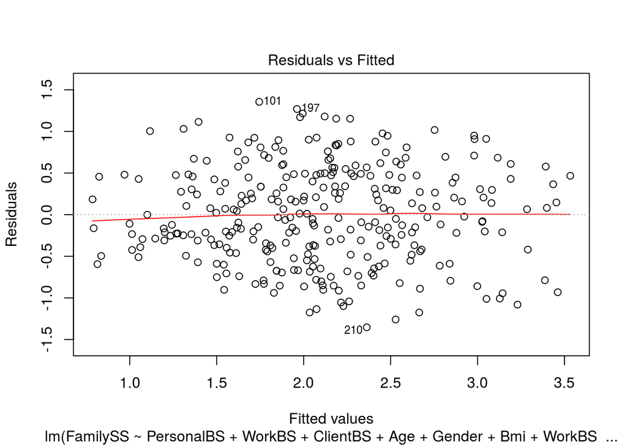

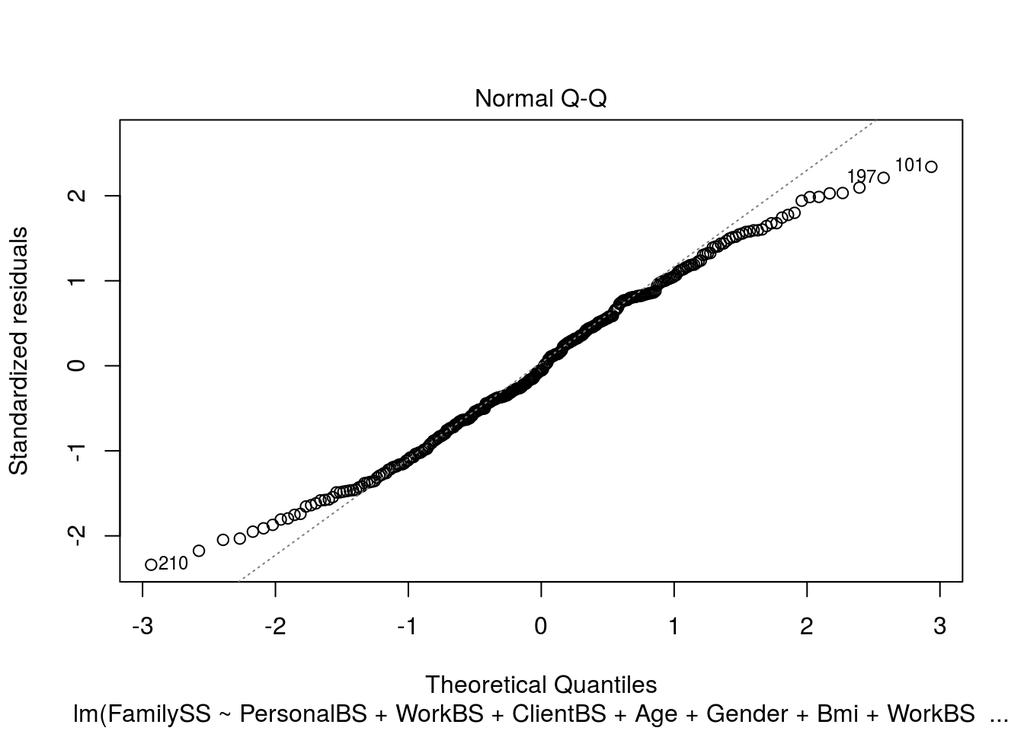

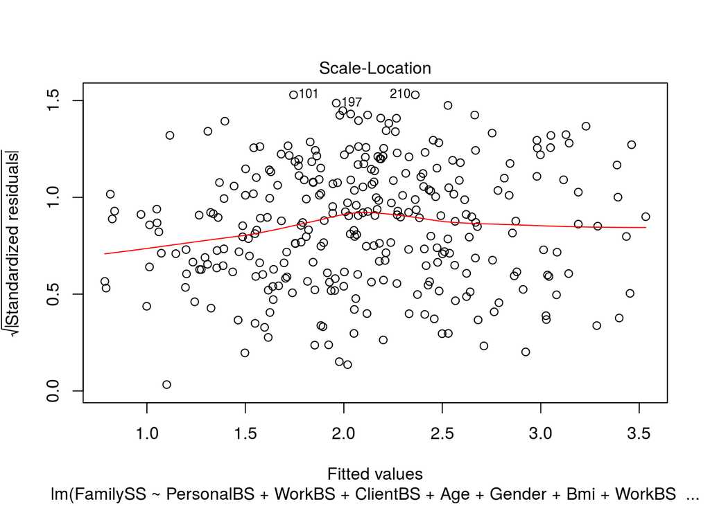

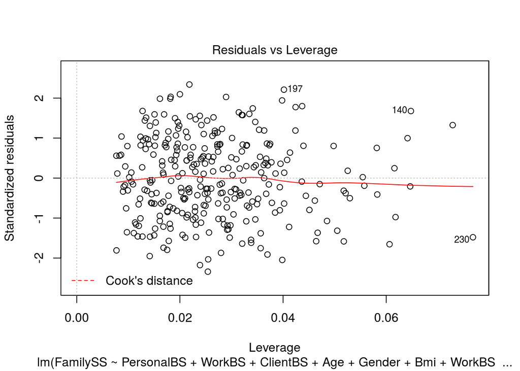

```r
plot(prelim.final.model)
```

Residual appear to be linear. Homoscedasticity is shown as in the plot above. Assumption for equal variance and linearity met.

### Fitted Values, residuals and influentials value

```r
resmod<-residuals(prelim.final.model)
head(resmod)
```

```
##          1          2          3          4          5          6
##  0.3262136  0.0130057  0.2267425 -0.3225038 -0.2156091 -0.3653168
```

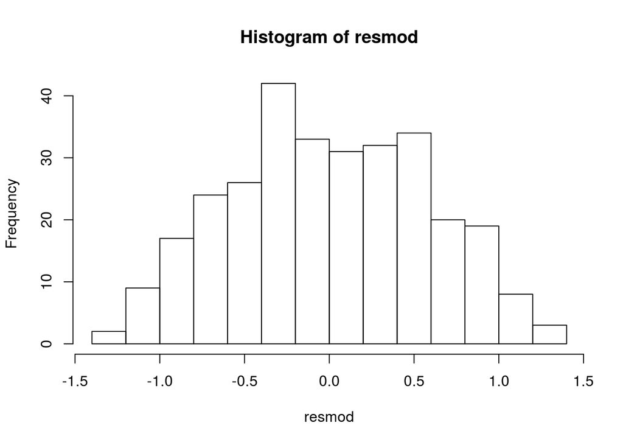

```r
hist(resmod)
```

histogram of residuals is appear to be normally distributed thus assumption for normality is met.

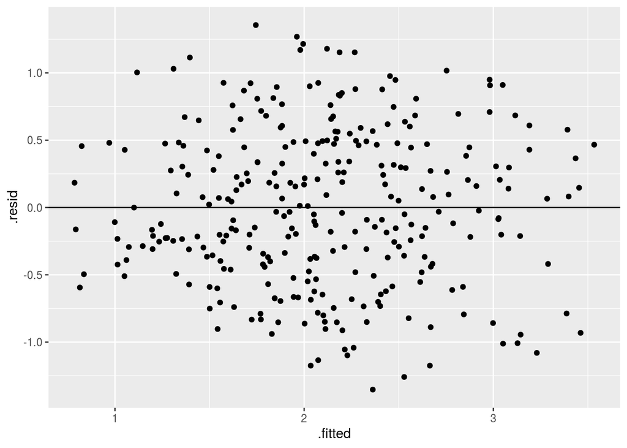

```r
ggplot(data = prelim.final.model, aes(x=.fitted,y=.resid))+geom_point()+geom_hline(yintercept=0)
```

residual appeared to be randomly scattered. Assumption for equal variance is met.

```r
library(broom)
library(knitr)
kable(head(augment(prelim.final.model)))
```

| FamilySS | PersonalBS | WorkBS | ClientBS | Age | Gender | Bmi | .fitted | .se.fit | .resid | .hat | .sigma | .cooksd | .std.resid |
| --- | --- | --- | --- | --- | --- | --- | --- | --- | --- | --- | --- | --- | --- |
| 2.21 | 2.33 | 2.38 | 2.57 | 35 | Male | 22.67574 | 1.883786 | 0.0513152 | 0.3262136 | 0.0076799 | 0.5862484 | 0.0003026 | 0.5592510 |
| 1.99 | 2.26 | 3.59 | 2.22 | 43 | Male | 33.28402 | 1.976994 | 0.1378854 | 0.0130057 | 0.0554495 | 0.5865621 | 0.0000038 | 0.0228534 |
| 1.87 | 2.46 | 2.20 | 2.60 | 56 | Female | 21.64446 | 1.643258 | 0.1137487 | 0.2267425 | 0.0377358 | 0.5864061 | 0.0007638 | 0.3947447 |
| 1.83 | 3.39 | 1.79 | 3.46 | 56 | Male | 22.65625 | 2.152504 | 0.1258100 | -0.3225038 | 0.0461627 | 0.5862431 | 0.0019239 | -0.5639339 |
| 1.22 | 2.48 | 1.80 | 1.81 | 56 | Male | 18.51852 | 1.435609 | 0.1336941 | -0.2156091 | 0.0521297 | 0.5864189 | 0.0009833 | -0.3782015 |
| 1.69 | 3.13 | 1.80 | 2.91 | 54 | Female | 27.60945 | 2.055317 | 0.1174123 | -0.3653168 | 0.0402057 | 0.5861552 | 0.0021235 | -0.6368119 |

```r
kable(tail(augment(prelim.final.model)))
```

| FamilySS | PersonalBS | WorkBS | ClientBS | Age | Gender | Bmi | .fitted | .se.fit | .resid | .hat | .sigma | .cooksd | .std.resid |
| --- | --- | --- | --- | --- | --- | --- | --- | --- | --- | --- | --- | --- | --- |
| 1.82 | 1.51 | 3.83 | 1.61 | 39 | Female | 19.38578 | 1.361588 | 0.1306740 | 0.4584121 | 0.0498012 | 0.5859144 | 0.0042257 | 0.8031180 |
| 1.14 | 1.98 | 2.86 | 3.55 | 29 | Male | 24.05693 | 2.002569 | 0.0849167 | -0.8625687 | 0.0210304 | 0.5843321 | 0.0059521 | -1.4888112 |
| 2.60 | 2.87 | 3.93 | 2.34 | 45 | Male | 22.34352 | 2.428040 | 0.1061671 | 0.1719601 | 0.0328731 | 0.5864730 | 0.0003789 | 0.2986183 |
| 1.79 | 3.22 | 2.31 | 2.77 | 45 | Female | 25.25952 | 2.270571 | 0.0776753 | -0.4805713 | 0.0175965 | 0.5858736 | 0.0015351 | -0.8280249 |
| 2.43 | 2.16 | 2.21 | 3.93 | 32 | Male | 23.02568 | 1.943606 | 0.0966720 | 0.4863944 | 0.0272560 | 0.5858498 | 0.0024844 | 0.8422089 |
| 1.15 | 1.97 | 3.27 | 3.38 | 51 | Female | 22.37568 | 1.611499 | 0.1161897 | -0.4614986 | 0.0393728 | 0.5859128 | 0.0033128 | -0.8041249 |

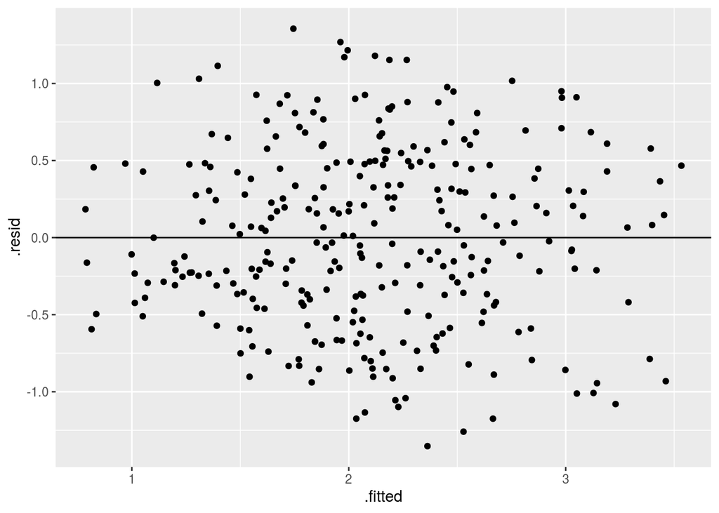

```r
ggplot(data = prelim.final.model,
       aes(x=.fitted, y=.resid)) +
  geom_point() +
  geom_hline(yintercept = 0)
```

### intepretation of scatter plot of residual and predicted

based on scattered plot of residual vs predicted: 1) for each x value, there is subpopulation of y value that is normally distributed 2) the variance for the subopulations is equal

### Prediction

```r
new_data<-expand.grid(PersonalBS = c(0.5,2.0,3.5),
                      WorkBS = c(0.5, 2.5, 3.5),
                      ClientBS = c(0.5,2.0,3.5),
                      Age = c(24,50,53),
                      Gender = c("Male","Female"),
                      Bmi = c(18,20,30))
data4<-augment(prelim.final.model, newdata = new_data)
summary(data4)
```

```
##    PersonalBS      WorkBS         ClientBS        Age           Gender
##  Min.   :0.5   Min.   :0.500   Min.   :0.5   Min.   :24.00   Male  :243
##  1st Qu.:0.5   1st Qu.:0.500   1st Qu.:0.5   1st Qu.:24.00   Female:243
##  Median :2.0   Median :2.500   Median :2.0   Median :50.00
##  Mean   :2.0   Mean   :2.167   Mean   :2.0   Mean   :42.33
##  3rd Qu.:3.5   3rd Qu.:3.500   3rd Qu.:3.5   3rd Qu.:53.00
##  Max.   :3.5   Max.   :3.500   Max.   :3.5   Max.   :53.00
##       Bmi           .fitted           .se.fit
##  Min.   :18.00   Min.   :-0.1921   Min.   :0.08361
##  1st Qu.:18.00   1st Qu.: 0.7785   1st Qu.:0.13224
##  Median :20.00   Median : 1.4797   Median :0.16464
##  Mean   :22.67   Mean   : 1.4793   Mean   :0.15803
##  3rd Qu.:30.00   3rd Qu.: 2.1398   3rd Qu.:0.18088
##  Max.   :30.00   Max.   : 3.1361   Max.   :0.22298
```

```r
data4
```

```
## # A tibble: 486 x 8
##    PersonalBS WorkBS ClientBS   Age Gender   Bmi .fitted .se.fit
##         <dbl>  <dbl>    <dbl> <dbl> <fct>  <dbl>   <dbl>   <dbl>
##  1        0.5    0.5      0.5    24 Male      18   0.252   0.173
##  2        2      0.5      0.5    24 Male      18   1.13    0.182
##  3        3.5    0.5      0.5    24 Male      18   2.01    0.222
##  4        0.5    2.5      0.5    24 Male      18   0.768   0.145
##  5        2      2.5      0.5    24 Male      18   1.65    0.142
##  6        3.5    2.5      0.5    24 Male      18   2.52    0.179
##  7        0.5    3.5      0.5    24 Male      18   1.03    0.165
##  8        2      3.5      0.5    24 Male      18   1.90    0.156
##  9        3.5    3.5      0.5    24 Male      18   2.78    0.185
## 10        0.5    0.5      2      24 Male      18   0.429   0.165
## # … with 476 more rows
```

### Influentials

```r
influen.obs<-augment(prelim.final.model)%>%filter(.std.resid >2|.std.resid < -2 |.hat > 0.0533)
influen.obs
```

```
## # A tibble: 21 x 14
##    FamilySS PersonalBS WorkBS ClientBS   Age Gender   Bmi .fitted .se.fit
##       <dbl>      <dbl>  <dbl>    <dbl> <dbl> <chr>  <dbl>   <dbl>   <dbl>
##  1     1.99       2.26   3.59     2.22    43 Male    33.3   1.98   0.138
##  2     3.15       2.28   3.58     2.21    31 Female  18.5   1.98   0.0996
##  3     2.06       3.62   3.95     2.36    43 Female  32.0   2.61   0.146
##  4     2.67       3.47   2.94     2.85    29 Male    37.4   2.79   0.149
##  5     3.21       2.21   2.25     3.26    26 Male    21.2   1.99   0.0828
##  6     3.22       3.8    4        3.69    29 Female  33.7   3.08   0.145
##  7     0.89       1.14   1.08     1.34    29 Female  31.2   0.999  0.138
##  8     2.73       2.15   4        2.97    39 Male    33.3   2.16   0.148
##  9     0.86       1.63   3.72     3.66    29 Male    22.9   2.03   0.117
## 10     3.1        1.95   1.99     3.46    34 Female  23.1   1.74   0.0865
## # … with 11 more rows, and 5 more variables: .resid <dbl>, .hat <dbl>,
## #   .sigma <dbl>, .cooksd <dbl>, .std.resid <dbl>
```

```r
non.influen.obs<- augment(prelim.final.model)%>%filter (.std.resid < 2 & .std.resid > 0.0533)
non.influen.obs
```

```
## # A tibble: 139 x 14
##    FamilySS PersonalBS WorkBS ClientBS   Age Gender   Bmi .fitted .se.fit
##       <dbl>      <dbl>  <dbl>    <dbl> <dbl> <chr>  <dbl>   <dbl>   <dbl>
##  1     2.21       2.33   2.38     2.57    35 Male    22.7    1.88  0.0513
##  2     1.87       2.46   2.2      2.6     56 Female  21.6    1.64  0.114
##  3     1.93       1.84   2.69     3.22    49 Male    23.4    1.55  0.0969
##  4     2.74       2.79   2.7      1.96    34 Male    23.3    2.18  0.0688
##  5     2.44       2.96   1.89     3.39    38 Male    22.5    2.18  0.0807
##  6     3.43       2.69   2.69     4       26 Male    18.1    2.48  0.104
##  7     2.22       2.81   1.2      2.31    36 Female  29.7    2.00  0.112
##  8     2.75       2.16   2.14     3.43    36 Female  19.3    1.86  0.0867
##  9     3.06       3.23   3.11     2.2     34 Female  23.5    2.44  0.0812
## 10     2.64       1.85   3.6      2.34    47 Male    22.3    1.72  0.107
## # … with 129 more rows, and 5 more variables: .resid <dbl>, .hat <dbl>,
## #   .sigma <dbl>, .cooksd <dbl>, .std.resid <dbl>
```

### compare final model with and without influential observation

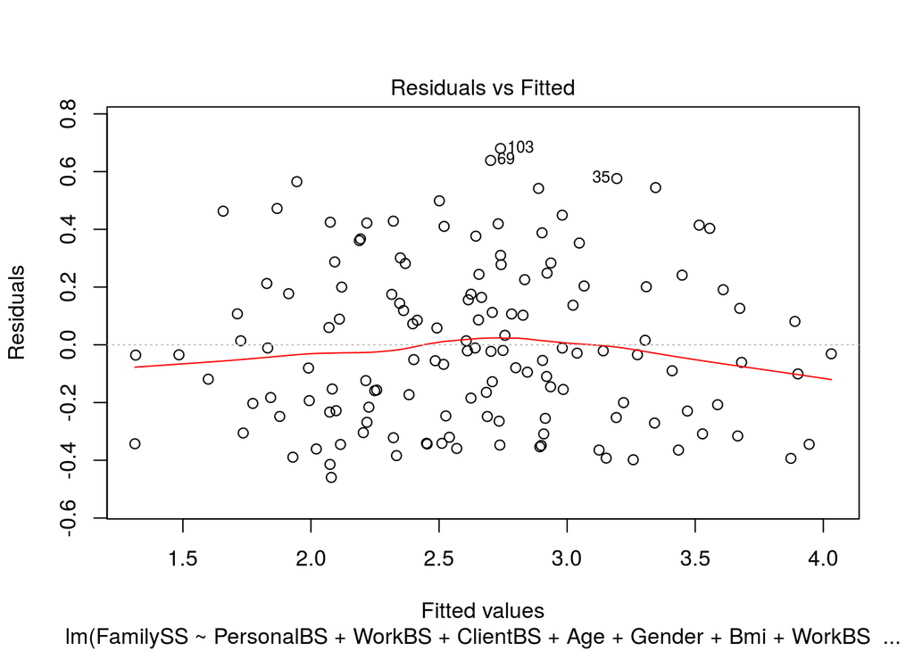

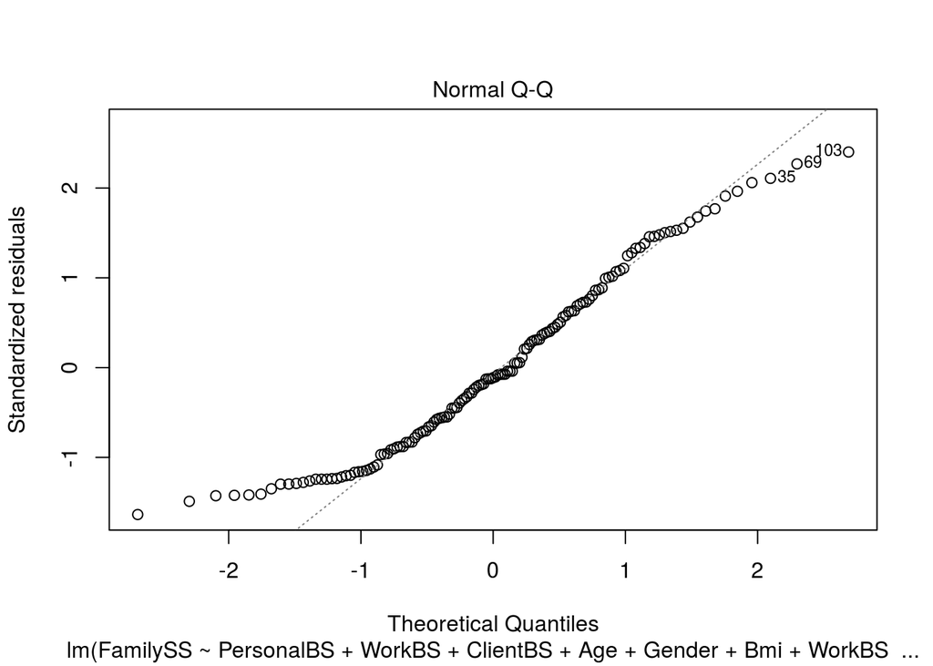

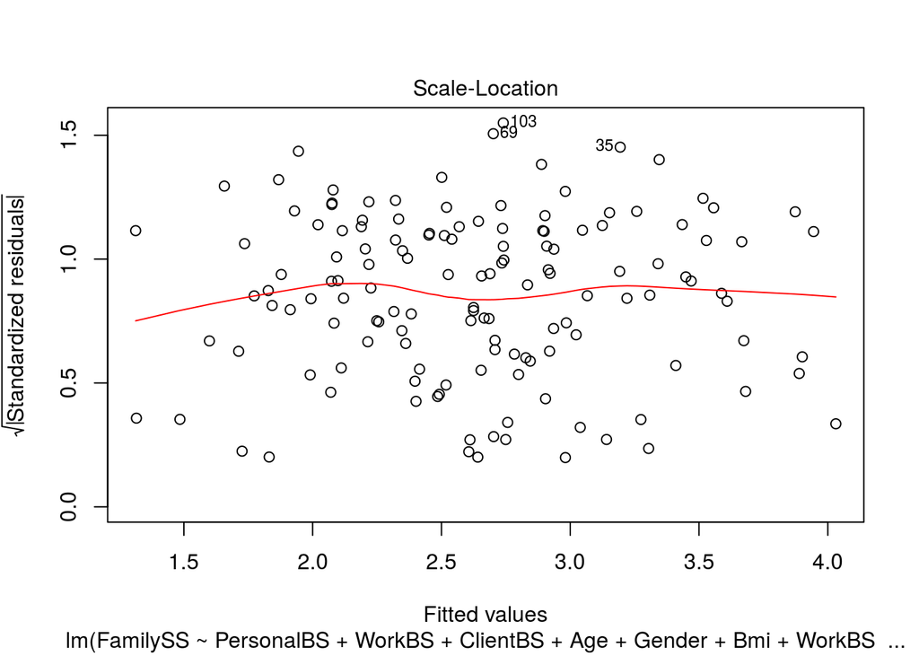

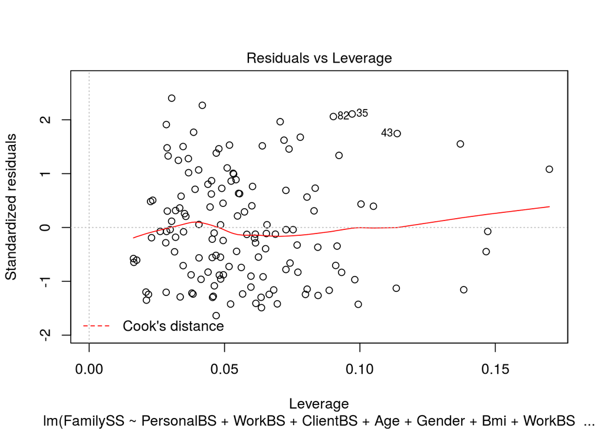

```r
finalmodel2<- lm(FamilySS~PersonalBS+WorkBS+ClientBS+Age+Gender+Bmi+WorkBS*Gender, data= non.influen.obs)
plot(finalmodel2)
```

```r
tidy(finalmodel2)
```

```
## # A tibble: 8 x 5
##   term              estimate std.error statistic  p.value
##   <chr>                <dbl>     <dbl>     <dbl>    <dbl>
## 1 (Intercept)        0.941     0.268       3.51  6.10e- 4
## 2 PersonalBS         0.565     0.0390     14.5   4.82e-29
## 3 WorkBS             0.0388    0.0464      0.836 4.05e- 1
## 4 ClientBS           0.145     0.0388      3.74  2.72e- 4
## 5 Age               -0.0143    0.00346    -4.13  6.43e- 5
## 6 GenderMale        -0.470     0.173      -2.72  7.42e- 3
## 7 Bmi                0.00481   0.00739     0.650 5.17e- 1
## 8 WorkBS:GenderMale  0.218     0.0602      3.63  4.05e- 4
```

## Final Model

```r
tidy(prelim.final.model, conf.int = T)
```

```
## # A tibble: 8 x 7
##   term             estimate std.error statistic  p.value conf.low conf.high
##   <chr>               <dbl>     <dbl>     <dbl>    <dbl>    <dbl>     <dbl>
## 1 (Intercept)       0.561     0.340       1.65  9.94e- 2  -0.107    1.23
## 2 PersonalBS        0.586     0.0535     11.0   1.28e-23   0.480    0.691
## 3 WorkBS            0.0860    0.0622      1.38  1.68e- 1  -0.0364   0.208
## 4 ClientBS          0.118     0.0544      2.17  3.10e- 2   0.0109   0.225
## 5 Age              -0.0145    0.00456    -3.18  1.62e- 3  -0.0235  -0.00554
## 6 GenderMale       -0.407     0.224      -1.82  7.03e- 2  -0.848    0.0340
## 7 Bmi              -0.00192   0.00968    -0.199 8.43e- 1  -0.0210   0.0171
## 8 WorkBS:GenderMa…  0.172     0.0812      2.11  3.53e- 2   0.0119   0.332
```

### Final Model Equation

Family Stressor Score = 0.561 + 0.586(Personal Burnout Score) + 0.086(Work Burnout Score) +0.118(Client Burnout Score) - 0.0145(Age) - 0.407(Male) - 0.002(Bmi) + 0.172 (WorkBS*GenderMale)

### Final Model Intepretation

49.2% of variability in Family Stressor Score is explained by model3.4

Those who increase 1 unit of Personal Burnout Score, the Family Stressor Score will be increase by 0.586 unit (95% CI = 0.480, 0.691) when adjusted with Work Burnout Score, Client Burnout Score, Age, Male, Bmi and WorkBS*GenderMale.

### Model Defend

The model is the best fitted model and most biologically sound. The model are able to explain 49.2% of variation of Family Stressor Score.